# canoe_drag_template (1) (1)

## Model

> Use $\LaTeX$ to describe precisely, in mathematical terms, how you are modeling a canoe moving through the water. Use quadratic drag as discussed in class.

First, let's identify key variables that we plan to use in the model.

$F =$ total force, $m =$ mass, $a =$ acceleration, and $t = $ time

We have our basic formula for force: $F = ma$

But we also have this formula for force in relation to the Canoe $F = F_p - F_d$, where $F_p$ = propulsion force. and $F_d$ = drag force.

Drag Force can be further broken down into this formula, where $F_d = cV^2$, where $c = $ boat size and $V =$ velocity.

So we have the formula $F_p - cV^2 = ma$.

However, $a$ can be rewritten as $a = \frac{dV}{dt}$ which appromixates to $\frac{V_{t+\delta t} - V_t}{\delta t}$

Our final formula should result in $ (\frac{F_p -cV_t^2}{m}) \delta_t + V_t = V_{t+\delta_t}$

## Code

> Fill in the function skeleton below to implement your model

```python
import numpy as np
import matplotlib.pyplot as plt
from scipy.interpolate import CubicSpline
%matplotlib inline
```

```python
def paddle(v0 = 0,
           force = lambda x: 300,
           cdrag = 40,
           ttotal = 5,
           mass = 80,
           tdelta = 0.05,):
    """
    parameters
    ==========
    v0:     initial velocity in m/s
    force:  force function in Newtons
    cdrag:  coefficient of drag for hull
    ttotal: total simulation time in seconds
    mass:   mass of boat, paddler, and equipment in kg
    delta:  time step interval in seconds

    results
    =======
    velocity: vector of velocity in m/s
    time:     vector of corresponding time points in seconds
    """
    pass

# Write more helper functions as necessary.
# For example, a plotting function that sets the correct
# x and y labels is handy.
```

Also, I'm going to create a few helper functions that will help the function run more efficiently, and to run the more circumstantial situations

```python
def paddlegraph(x_array = np.array([0,1]), y_array = np.array([1,1]), xaxis = 'time', yaxis = 'velocity', **kwargs):
    '''
    function will take two numpy arrays, and two strings as an argument, and plot the arrays using matplotlib using one
    string as the title of the x-axis, and other string as the label for the y-axis
    '''
    plt.xlabel(xaxis, **kwargs)
    plt.ylabel(yaxis, **kwargs)
    plt.plot(x_array, y_array)
```

```python
def motor(time, force = 300):
    out = np.empty_like(time)
    out[:] = force
    return out
```

```python
def paddle(v0 = 0,
           force = 300,
           cdrag = 40,
           ttotal = 5,
           mass = 80,
           tdelta = .05,):
    """
    parameters
    ==========
    v0:     initial velocity in m/s
    force:  force function in Newtons
    cdrag:  coefficient of drag for hull
    ttotal: total simulation time in seconds
    mass:   mass of boat, paddler, and equipment in kg
    delta:  time step interval in seconds

    results
    =======
    velocity: vector of velocity in m/s
    time:     vector of corresponding time points in seconds
    """
    time = np.linspace(0, ttotal, int(ttotal//tdelta+1))
    velocity = np.zeros_like(time)
    print("Is the force a motor? Please type 'yes' or 'no'")
    split1 = input()
    if split1 == 'yes':
        for y in range(len(time)):
            dragforce = cdrag*v0**2
            mforce = motor(time, force)
            tforce = mforce[y] - dragforce
            velocity[y] = tforce/mass * tdelta + v0
            v0 = velocity[y]
    else:
        print("How many times is the person paddling in "+ str(ttotal) + " seconds? Please round to the nearest whole number")
        Prate = input()
    paddlegraph(time, velocity, 'time', 'velocity')
```

## Experiment

> Test your function and show plots of velocity against time for two cases:
> 1. A constant steady propulsive force representing a motor.
> 2. A periodic propulsive force representing a human paddler.

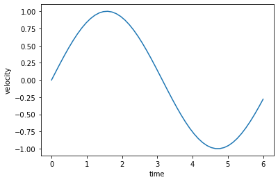

```python
# TODO: Experiment code
#experiment one, testing the helper function to make sure it is working properly
a = np.linspace(0, 6)
b = np.sin(a)
paddlegraph(a,b)
```

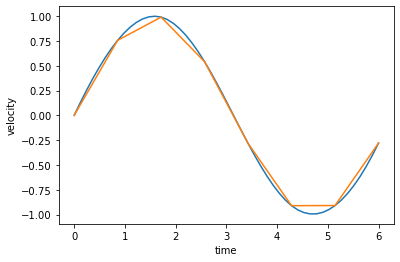

```python
#Experimenting with interpolation and CubicSpline
c = np.linspace(0, 6, 8)
g = np.sin(c)
d = np.interp(a, c, g)
f = CubicSpline(c,g)
paddlegraph(a, f(a))
paddlegraph(c,g)
```

```
Is the force a motor? Please type 'yes' or 'no'
yes
```

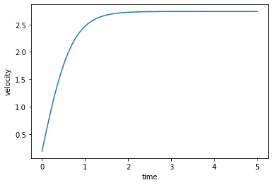

```python
#testing if the function works using all the defaults but with a constant propulsive force of 300
paddle()
```

```
Is the force a motor? Please type 'yes' or 'no'
no
How many times is the person paddling in 5 seconds? Please round to the nearest whole number
```

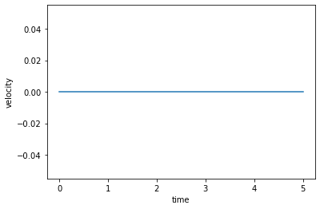

```python
paddle()
```

```python
CubicSpline?
```